# CLSA COVID Epigenetic Sensitivity Analysis

RSF

2022-07-15

Note: These sensitivity analyses were conducted based off of code written by Ms. Amy Inkster.

#1: Set-up

This section creates a table called ProbeInfo that houses information on all the CpGs probed by the EPIC array, including what chromosome/gene/genic region they are part of, I use this later to pull out probes on the X and Y for sex checks.

```r
library(dplyr)
ProbeInfo <- as.data.frame(IlluminaHumanMethylationEPICanno.ilm10b4.hg19::Locations)
```

```
## Setting options('download.file.method.GEOquery'='auto')
```

```
## Setting options('GEOquery.inmemory.gpl'=FALSE)
```

```r
ProbeInfo$probeID <- rownames(ProbeInfo)
chrXprobes <- ProbeInfo %>% filter(chr %in% "chrX")
chrYprobes <- ProbeInfo %>% filter(chr %in% "chrY")
autoProbes <- ProbeInfo %>% filter(!(chr %in% c("chrX", "chrY")))
chrXYprobes <- ProbeInfo %>% filter(chr %in% c("chrX", "chrY"))
```

Read in the RAW beta values matrix from the CLSA. Should have probes as rows, samples as columns. Also read in the metadata that contains sample ID labels, and sex labels. The rest of this code assumes the betas object is probes (rows) x samples (columns).

```r
setwd("~/Desktop/UBC-Postdoctoral Fellowship/CLSA - Covid Analyses/epigenetics_clsa_s1478")

pDat <- read.csv("CLSA_metadata_FINA_Apr_2021-deidentified.csv")          ## change to reflect local path (if 1446 objects, then do not need the betas_filt file; if not, then load betas_filt)

betas_filt <- read.csv("CLSA.RAW_BETAS_Transposed_Apr2021.csv")         ## change to reflect local path
```

Install packages necessary for sensitivity analysis

```r
if(!"BiocManager" %in% installed.packages()) {
  install.packages("BiocManager")}
if(!"minfi" %in% installed.packages()) {
  BiocManager::install("minfi")}
if(!"IlluminaHumanMethylationEPICmanifest" %in% installed.packages()) {
  BiocManager::install("IlluminaHumanMethylationEPICmanifest")}
if(!"IlluminaHumanMethylationEPICanno.ilm10b4.hg19" %in% installed.packages()) {
  BiocManager::install("IlluminaHumanMethylationEPICanno.ilm10b4.hg19")}
if(!"tidyverse" %in% installed.packages()) {
  BiocManager::install("tidyverse")}
if(!"remotes" %in% installed.packages()) {
  install.packages("remotes")}
if(!"ewastools" %in% installed.packages()) {
  remotes::install_github("hhhh5/ewastools")}

library(minfi)
```

```
## locfit 1.5-9.6    2022-07-11
```

```r
library(ewastools)
library(tidyverse)
library(IlluminaHumanMethylationEPICanno.ilm10b4.hg19)
```

```r
rs <- betas_filt[ , grepl("rs", names(betas_filt))]
dim(rs)
```

```
## [1] 1478   59
```

```r
head(rs)
```

```
##   rs10033147  rs1019916  rs1040870 rs10457834 rs10796216 rs10882854 rs10936224
## 1  0.4792010 0.47233050 0.44476090  0.5312150  0.4582379  0.9770364 0.90054810
## 2         NA 0.45663480 0.48337230  0.9526839  0.4708189  0.9604329 0.45760290
## 3  0.5297728 0.04143751 0.47441650  0.9372860  0.4462544  0.4703201 0.50034190
## 4  0.9158413 0.03898670 0.97258730  0.4902555  0.4691511  0.9424877 0.49948720
## 5  0.5609177 0.44247310 0.05789553  0.4972706  0.4709968  0.9625401 0.92306110
## 6  0.9539264 0.46828140 0.08077144  0.4913133  0.9467758  0.9498483 0.04368947
##   rs11034952 rs11249206 rs13369115   rs133860  rs1416770  rs1467387 rs1484127
## 1 0.04778984 0.02002487 0.94414210 0.96625780 0.02719900 0.04444076 0.9326967
## 2 0.08447043 0.02613712 0.52187500 0.01816648 0.03003426 0.03906423 0.9603187
## 3 0.97529460 0.93819660 0.49947150 0.95934920 0.93563740 0.06172934 0.9541410
## 4 0.52853190 0.46840560 0.07509422 0.46723460 0.50500800 0.51927110 0.4861832
## 5 0.52538440 0.03649949 0.93924130 0.96370170 0.03093584 0.04414675 0.4651160
## 6 0.07486960 0.94481600 0.92488940 0.95409060 0.95678120 0.05238528 0.9569378
##   rs1495031  rs1510189  rs1510480  rs1520670  rs1941955 rs1945975  rs2032088
```

[output cut: 48 more lines]

```r
genotypes <- call_genotypes(t(rs))

check_snp_agreement(genotypes, rownames(rs), rownames(rs)) # should be NULL (and is Null)
```

#3: Sex checks Now, check that reported sex in metadata table matches data itself from the sex chromosomes. Achieve this by clustering on the probes from both the X and Y chromosome, samples should separate by sex.

First, we pull beta values associated with the X and Y chromosome

```r
betasxy <- betas_filt[,colnames(betas_filt) %in% chrXYprobes$probeID]
```

Next, run pca on these probes

```r
sum(is.na(betasxy))
```

```
## [1] 103549
```

```r
test <- na.omit(t(betasxy)) # drop NAs

pc_obj <- prcomp(t(test)) # run pca
pc_matrix <- pc_obj$x # extract PC scores
```

We then create a dataframe where all participants with genotypic data are only included, and then organize them by epigenetic testing number

```r
setwd("~/Desktop/UBC-Postdoctoral Fellowship/CLSA - Covid Analyses/21CON001_McMasterU_PRaina_Baseline")
Genedata<-read.csv("21CON001_McMasterU_PRaina_CoP5_2_Baseline.csv")#Processed Baseline + Follow-up 1 + COVID Questionnaire
Genedata<-subset(Genedata, !is.na(AgeAccelerationDifference_COM)) #Subset to only participants with genetic data
Genedata<-Genedata[c(25,2379)]

library(dplyr)
Genedata<-arrange(Genedata, ADM_EPIGEN2_COM)
```

Finally, we plot PC1 and PC2 and color by the reported sex. There should be a clear separation between PC1 and PC2, wherein all males are located within one PC and all females are located within the other. In the event that some males were incorrectly located on the “wrong” PC (or vice-versa), then these individuals would need to be removed from the anlaysis.

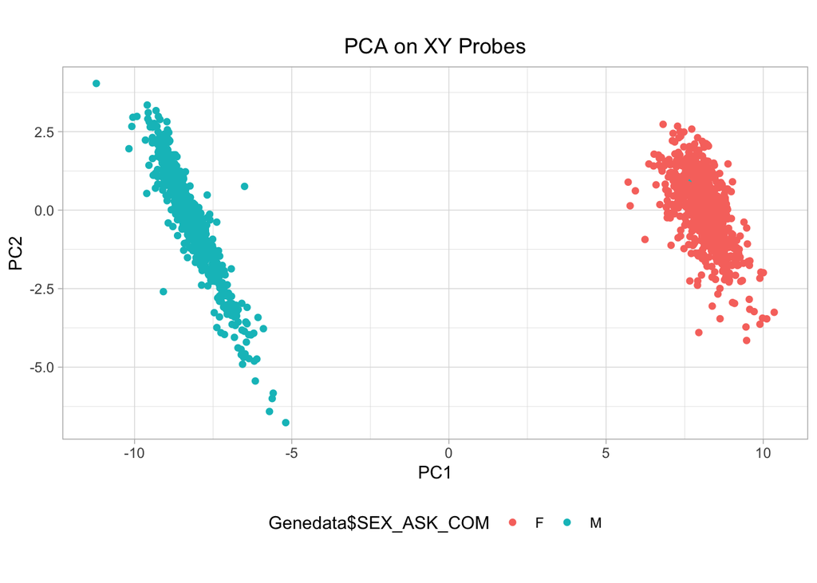

```r
pc_matrix %>%
  as.data.frame() %>%
  ggplot(aes(x=PC1, y=PC2, color = Genedata$SEX_ASK_COM)) +  ## change to column of pDat that contains sex info if not called "Sex"
  geom_point() +
  ggtitle("PCA on XY Probes") +
  theme_light() +
  theme(legend.position = "bottom", plot.title = element_text(hjust=0.5)) +
  coord_equal(ratio=1)
```